# Assignment 7

Darren Jeng

November 4, 2016

## Maternal mortality tidy

Below you can see the steps taken to tidy the Morality data. Regarding the warnings, as the varaibles are changed to numeric, any value that was a blank turns to “NA.” Once that was done, we then take a look at the Income data.

```r
# Reading csv file from my github
Mortal <- read.csv("https://raw.githubusercontent.com/KaiJeng/AssignmentSeven/master/data/xmart.csv")
names(Mortal) <- make.names(names(Mortal))
names(Mortal)[3] <- "Maternal.Mortality.Ratio"
names(Mortal)[4] <- "Birth.Attend.Percentage"

# Create and clean new variables
Mortal$lower_bound <- str_extract_all(Mortal$Maternal.Mortality.Ratio,"\\[[0-9]? [0-9]+")
Mortal$lower_bound <- str_replace_all(Mortal$lower_bound,"\\[ ","")
Mortal$lower_bound <- str_replace_all(Mortal$lower_bound,"\\[","")
Mortal$lower_bound <- str_replace_all(Mortal$lower_bound," ","")
Mortal$lower_bound <- as.numeric(Mortal$lower_bound)
```

```
## Warning: NAs introduced by coercion
```

```r
Mortal$lower_bound[is.na(Mortal$lower_bound)] <- 0

Mortal$upper_bound <- str_extract_all(Mortal$Maternal.Mortality.Ratio,"[0-9]? [0-9]+\\]$")
Mortal$upper_bound <- str_replace_all(Mortal$upper_bound," ","")
Mortal$upper_bound <- str_replace_all(Mortal$upper_bound,"\\]","")
Mortal$upper_bound <- as.numeric(Mortal$upper_bound)
```

```
## Warning: NAs introduced by coercion
```

```r
Mortal$upper_bound[is.na(Mortal$upper_bound)] <- 0

Mortal$Mortality <- str_extract_all(Mortal$Maternal.Mortality.Ratio,"^[0-9]? ?[0-9]+")
Mortal$Mortality <- str_replace_all(Mortal$Mortality," ","")
Mortal$Mortality <- as.numeric(Mortal$Mortality)
Mortal$Mortality[is.na(Mortal$Mortality)] <- 0

# Some year observations has ranges. For the sake of simplicity, I use the earlier year out of the range.
Mortal$Year <- str_replace_all(Mortal$Year,"\\-[0-9]+$","")
Mortal$Year <- as.numeric(Mortal$Year)
# Get rid of old column
Mortal$Maternal.Mortality.Ratio <- NULL
```

## Gross national income tidy

Next, we take steps to tidy the income data as shown below. After some rearranging, we get separate variables for income and year.

```r
# Clean and tidy Income data
Income <- read.csv("https://raw.githubusercontent.com/KaiJeng/AssignmentSeven/master/data/WHS9_93.csv", skip = 1)
names(Income) <- make.names(names(Income))
Income$X.2013 <- str_replace_all(Income$X.2013," ","")
Income$X.2013 <- as.integer(Income$X.2013)
Income <- gather(Income, `X.2013`:`X.1990`, key = "Year", value = "Income")

# Clean variables
Income$Year <- str_replace_all(Income$Year,"X.","")
Income$Year <- as.numeric(Income$Year)
Income$Income <- as.numeric(Income$Income)
```

# Merging and Graphing

Now, we need to merge the two data sets. Using left join, we can merge the income data in respect to the morality data. Then, after creating two subsets of data, the graphs can be created.

```r
# Merge the data sets
Merger <- left_join(Mortal, Income, by = c("Country","Year"))
```

```r
Merger$Birth.Attend.Percentage[is.na(Merger$Birth.Attend.Percentage)] <- 0
Merger$Income[is.na(Merger$Income)] <- 0

# Filter data sets for first graph
NoticeMe <- Merger[,c("Country","Year","Birth.Attend.Percentage","Income")]
# Filter out observations that don't have values for one variable
NoticeMe <- filter(NoticeMe, NoticeMe$Income != 0)
NoticeMe <- filter(NoticeMe, NoticeMe$Birth.Attend.Percentage != 0)
Doctor <- NoticeMe %>% ggplot(mapping = aes(Birth.Attend.Percentage, Income)) + geom_point() + xlab("Births attended by skilled health personnel (%)") + ylab("Gross national income per capita (PPP int. $)") + ggtitle("Does attendence really matter?") + theme_solarized() + scale_colour_solarized()

# Filter data sets for second graph
WheresMom <- Merger[,c("Country","Year","lower_bound","upper_bound","Mortality","Income")]
# Filter out observations that don't have values for one variable (if lower_bound is zero, so is upper_bound and mortality)
WheresMom <- filter(WheresMom, WheresMom$lower_bound != 0)
WheresMom <- filter(WheresMom, WheresMom$Income != 0)
Gone <- WheresMom %>% ggplot(mapping = aes(Mortality, Income)) + geom_point() + xlab("Maternal mortality ratio (per 100,000 live births)") + ylab("Gross national income per capita (PPP int. $)") + ggtitle("Does Mom help make money?") + theme_solarized() + scale_colour_solarized()
```

With the graphs created, lets quickly analyze them both:

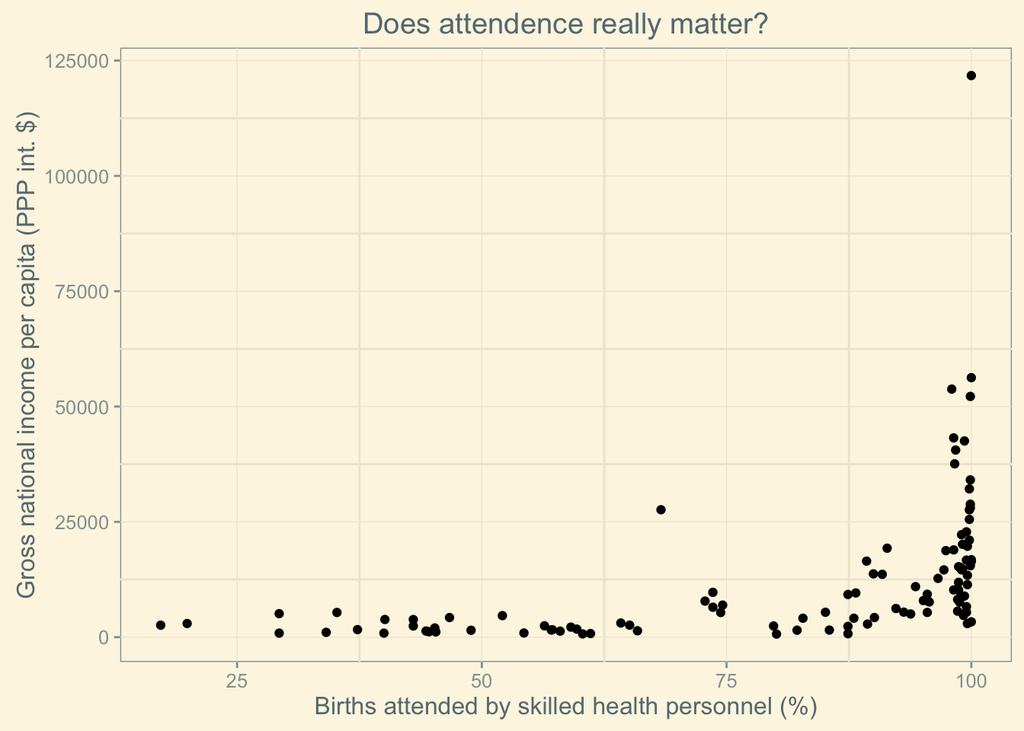

As the percentage of births attended by a skilled health personnel increases, the gross national income seem to stay low until it shoots up near the end somewhat exponentially (around 80-100%). What can be said about the data is that higher gross national incomes seem to be much more common when a country has a very high percentage of births attended by a skilled health personnel.

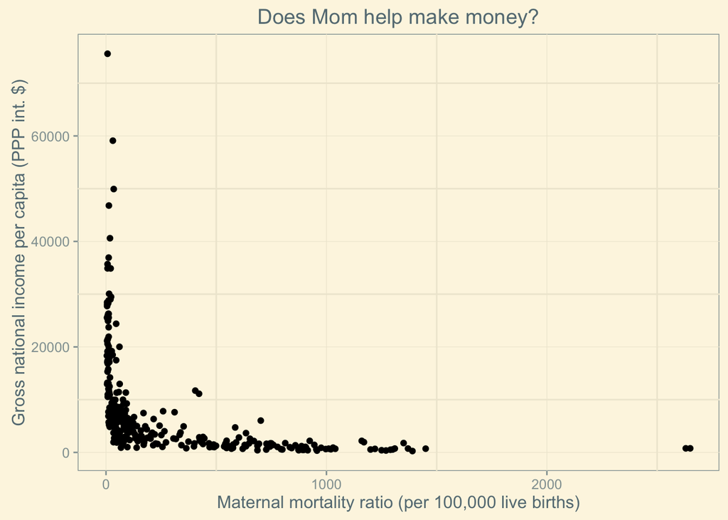

This graph is practically the opposite of the previous graph’s trend. At very low maternal mortality ratios, gross national income can be much greater as compared to higher maternal mortality ratios. High gross nation income thus seems to be possible only at very low maternal mortality ratios.

Now, we need to write a csv file of the merged data set from before. But since running the markdown will always write this file, I commentted it out. The csv (hopefully) is in the github repo already.

```r
# write_csv(Merger, path = "~/Documents/MSDS597/Assignment 7/data/merger.csv")
```

# Choropleth map

Lastly we need a choropleth mapping of maternal mortality. First though, we need to get the most recent year for each country in the merged dataset befoe choropleth can be used.

```r
# Totally borrowed this second line of code. First filter out observations that didn't have morality values then rank.
Merger <- filter(Merger, Merger$lower_bound != 0)
Merger$Rank <- ave(Merger$Year, Merger$Country, FUN = function(x) rank(-x, ties.method="first"))
Merger <- filter(Merger, Merger$Rank == 1)
```

With the most current year in the merged data for each country, we can now use choropleth.

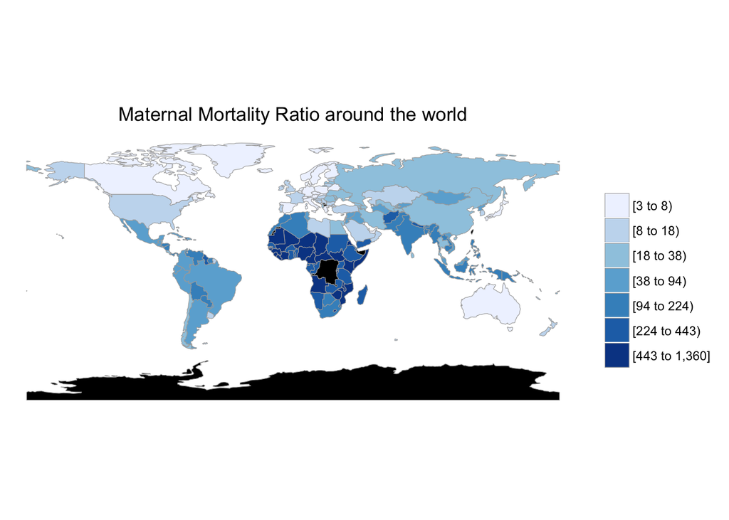

```r
ChoroMerge <- Merger[,c("Country","Mortality")]
names(ChoroMerge) <- c("region","value")
ChoroMerge$region <- tolower(ChoroMerge$region)

# And now, to manually change all names that don't work to ones that do work. Some regions aren't represented at all.
ChoroMerge$region <- str_replace_all(ChoroMerge$region,"republic of moldova","moldova")
ChoroMerge$region <- str_replace_all(ChoroMerge$region,"democratic people\\'s republic of korea","north korea")
ChoroMerge$region <- str_replace_all(ChoroMerge$region,"republic of korea","south korea")
ChoroMerge$region <- str_replace_all(ChoroMerge$region,"russian federation","russia")
ChoroMerge$region <- str_replace_all(ChoroMerge$region,"serbia","republic of serbia")
ChoroMerge$region <- str_replace_all(ChoroMerge$region,"syrian arab republic","syria")
ChoroMerge$region <- str_replace_all(ChoroMerge$region,"timor\\-leste","east timor")
ChoroMerge$region <- str_replace_all(ChoroMerge$region,"bahamas","the bahamas")
ChoroMerge$region <- str_replace_all(ChoroMerge$region,"venezuela \\(bolivarian republic of\\)", "venezuela")
ChoroMerge$region <- str_replace_all(ChoroMerge$region,"viet nam","vietnam")
ChoroMerge$region <- str_replace_all(ChoroMerge$region,"bolivia \\(plurinational state of\\)","bolivia")
ChoroMerge$region <- str_replace_all(ChoroMerge$region,"brunei darussalam","brunei")
ChoroMerge$region <- str_replace_all(ChoroMerge$region,"cote d\\'ivoire","ivory coast")
ChoroMerge$region <- str_replace_all(ChoroMerge$region,"congo","republic of congo")
ChoroMerge$region <- str_replace_all(ChoroMerge$region,"united kingdom of great britain and northern ireland","united kingdom")
ChoroMerge$region <- str_replace_all(ChoroMerge$region,"guinea\\-bissau","guinea bissau")
ChoroMerge$region <- str_replace_all(ChoroMerge$region,"iran \\(islamic republic of\\)","iran")
ChoroMerge$region <- str_replace_all(ChoroMerge$region,"lao people\\'s democratic republic","laos")

country_choropleth(ChoroMerge, title="Maternal Mortality Ratio around the world")
```

Countries in black either did not have data or was missed out somehow somewhere along the journey. The higher maternal mortality ratios are mostly located in Africa while more developed contries showing lower ratios.